# Suicidal ideation and adolescent friendship networks — Supplement

## Degree Distributions

In-degree is how many people named someone; out-degree is how many people a respondent named, which is capped at 10 (5 male + 5 female nominations). The x-axis stops at 20; anyone above 20 is counted in the “20+” bar.

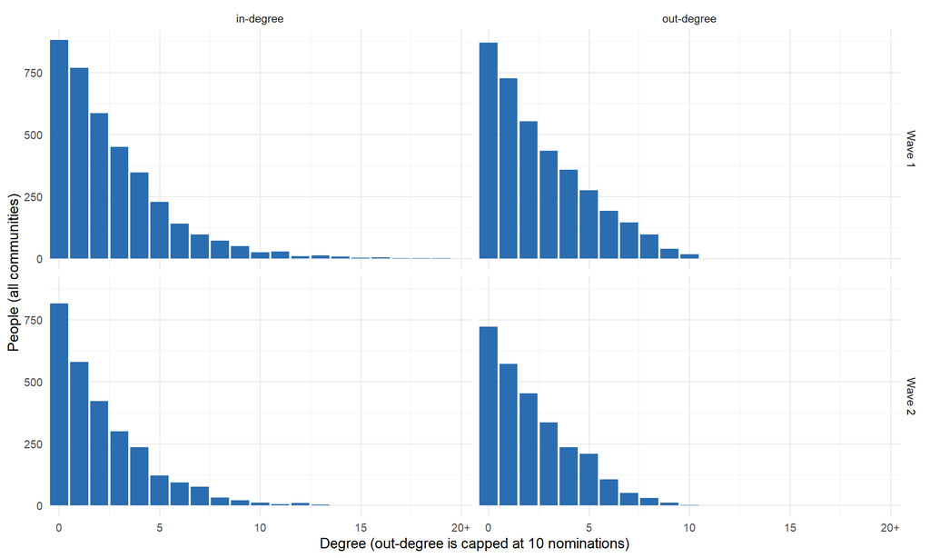

Degree summaries across communities

| Wave | Direction | Mean degree (median community) | Share with degree 0 (median) | Share at the cap of 10 (median) |
| --- | --- | --- | --- | --- |
| 1 | in | 2.15 | 31.3% | 0.3% |
| 1 | out | 2.15 | 26.4% | 0.0% |
| 2 | in | 2.31 | 27.3% | 0.0% |
| 2 | out | 2.31 | 19.4% | 0.0% |

# 2. Wave 1 Directed ERGMs

**Show ERGM models:** m14a m14c m14d

## Pooled Results

Pooled estimates for every model, side by side. Each cell shows the pooled log-odds estimate with stars (`+` p<.1, `*` p<.05, `**` p<.01, `***` p<.001), its SE in parentheses, the **95% prediction interval** in blue, and **k**, the number of communities pooled. The prediction interval is the range expected for a new community. When it is much wider than the CI, communities genuinely differ and the average describes them less well. Use the checkboxes above to hide models.

Pooled wave 1 ERGM estimates across communities

| Term | m14a | m14c | m14d |
| --- | --- | --- | --- |
| Edges | -4.263*** (0.337) [-6.57, -1.95] k = 12 | -4.746*** (0.694) [-9.05, -0.44] k = 10 | -5.181*** (0.546) [-8.19, -2.17] k = 10 |
| Ideation status homophily | 0.186** (0.070) [-0.07, 0.44] k = 10 | 0.612* (0.302) [-1.11, 2.33] k = 9 | 0.322 (0.252) [-1.10, 1.75] k = 9 |
| Ideation: receiver | 0.137<sup>+</sup> (0.076) [-0.15, 0.43] k = 10 | 0.538<sup>+</sup> (0.287) [-1.07, 2.15] k = 9 | 0.415 (0.258) [-1.03, 1.86] k = 9 |
| Ideation: sender | 0.069<sup>+</sup> (0.040) [-0.01, 0.15] k = 10 | 0.427 (0.303) [-1.29, 2.15] k = 9 | 0.033 (0.304) [-1.72, 1.78] k = 9 |
| Reciprocity | — | 2.196*** (0.232) [0.81, 3.58] k = 10 | 2.460*** (0.426) [-0.24, 5.16] k = 10 |
| GW in-degree (decay=0.5) | — | -0.554* (0.265) [-1.97, 0.86] k = 10 | -0.888** (0.324) [-2.79, 1.01] k = 10 |
| GW out-degree (decay=0.5) | — | -1.772** (0.540) [-5.09, 1.54] k = 10 | -1.907*** (0.268) [-3.38, -0.43] k = 10 |
| GW shared partners, OSP (decay=0.25) | — | 0.551** (0.199) [-0.58, 1.68] k = 10 | 0.457* (0.182) [-0.62, 1.53] k = 10 |
| GW shared partners, ISP (decay=0.25) | — | 0.802* (0.386) [-1.58, 3.19] k = 10 | 0.477* (0.187) [-0.63, 1.58] k = 10 |
| GW dyadwise shared partners, OSP (decay=0.25) | — | 0.004 (0.038) [-0.22, 0.23] k = 10 | -0.033 (0.022) [-0.16, 0.09] k = 10 |
| GW dyadwise shared partners, ISP (decay=0.25) | — | -0.116 (0.088) [-0.67, 0.44] k = 10 | -0.128*** (0.031) [-0.31, 0.05] k = 10 |
| Shared club membership | — | 0.384*** (0.071) [0.01, 0.76] k = 9 | 0.447*** (0.099) [-0.12, 1.01] k = 9 |
| Same gender | — | 0.281*** (0.028) [0.23, 0.33] k = 10 | 0.199* (0.088) [-0.31, 0.70] k = 10 |
| Same grade | — | 1.045*** (0.142) [0.18, 1.91] k = 10 | 1.105*** (0.181) [-0.02, 2.23] k = 10 |
| Depressive symptoms: receiver | — | — | -0.000 (0.005) [-0.02, 0.02] k = 10 |
| Depressive symptoms: sender | — | — | 0.003 (0.005) [-0.02, 0.03] k = 10 |
| Social support: receiver | — | — | 0.194<sup>+</sup> (0.116) [-0.49, 0.88] k = 10 |
| Social support: sender | — | — | 0.047<sup>+</sup> (0.027) [-0.01, 0.10] k = 10 |
| Communities fit | 13 | 13 | 13 |
| of which small, not pooled | 1 | 2 | 2 |
| Failed / degenerate / timed out | 3 | 3 | 3 |
| Too small / too few events | 0 | 0 | 0 |
| With terms dropped | 3 | 3 | 3 |

### Do community characteristics explain the differences?

For models with `moderators` in `config/ergm_model_desc.csv`, each term’s per-community estimates are regressed on community-level variables (meta-regression; An 2015). A significant moderator means the effect differs systematically with that characteristic. R² is the share of between-community variance explained.

| Model | Term | Moderator | Estimate | SE | p | R² (%) | k |
| --- | --- | --- | --- | --- | --- | --- | --- |
| m14d | Shared club membership | log(n_nodes) | 0.202 | 0.060 | 0.0007 | 67 | 9 |
| m14d | Shared club membership | ideation_prev_w1 | 0.968 | 3.201 | 0.76 | 67 | 9 |
| m14d | Edges | log(n_nodes) | -0.693 | 0.482 | 0.15 | 20 | 10 |
| m14d | Edges | ideation_prev_w1 | 1.24e+01 | 2.22e+01 | 0.58 | 20 | 10 |
| m14d | GW dyadwise shared partners, ISP (decay=0.25) | log(n_nodes) | -0.030 | 0.028 | 0.28 | 9 | 10 |
| m14d | GW dyadwise shared partners, ISP (decay=0.25) | ideation_prev_w1 | -0.207 | 1.249 | 0.87 | 9 | 10 |
| m14d | GW dyadwise shared partners, OSP (decay=0.25) | log(n_nodes) | -0.023 | 0.014 | 0.093 | 65 | 10 |
| m14d | GW dyadwise shared partners, OSP (decay=0.25) | ideation_prev_w1 | 2.087 | 0.729 | 0.0042 | 65 | 10 |
| m14d | GW shared partners, ISP (decay=0.25) | log(n_nodes) | 0.161 | 0.153 | 0.29 | 32 | 10 |
| m14d | GW shared partners, ISP (decay=0.25) | ideation_prev_w1 | 8.853 | 6.470 | 0.17 | 32 | 10 |
| m14d | GW shared partners, OSP (decay=0.25) | log(n_nodes) | -0.002 | 0.199 | 0.99 | 0 | 10 |
| m14d | GW shared partners, OSP (decay=0.25) | ideation_prev_w1 | 0.731 | 8.089 | 0.93 | 0 | 10 |
| m14d | GW in-degree (decay=0.5) | log(n_nodes) | -0.191 | 0.330 | 0.56 | 0 | 10 |
| m14d | GW in-degree (decay=0.5) | ideation_prev_w1 | 1.43e+01 | 1.41e+01 | 0.31 | 0 | 10 |
| m14d | GW out-degree (decay=0.5) | log(n_nodes) | -0.334 | 0.235 | 0.16 | 14 | 10 |
| m14d | GW out-degree (decay=0.5) | ideation_prev_w1 | 1.185 | 1.10e+01 | 0.91 | 14 | 10 |
| m14d | Reciprocity | log(n_nodes) | 1.132 | 0.200 | 1.5e-08 | 81 | 10 |
| m14d | Reciprocity | ideation_prev_w1 | -1.07e+01 | 8.084 | 0.18 | 81 | 10 |
| m14d | Depressive symptoms: receiver | log(n_nodes) | 0.001 | 0.005 | 0.87 | 0 | 10 |
| m14d | Depressive symptoms: receiver | ideation_prev_w1 | -0.011 | 0.242 | 0.96 | 0 | 10 |
| m14d | Ideation: receiver | log(n_nodes) | 0.487 | 0.175 | 0.0054 | 54 | 9 |
| m14d | Ideation: receiver | ideation_prev_w1 | -1.24e+01 | 9.633 | 0.2 | 54 | 9 |
| m14d | Social support: receiver | log(n_nodes) | -0.142 | 0.121 | 0.24 | 0 | 10 |
| m14d | Social support: receiver | ideation_prev_w1 | -0.195 | 5.036 | 0.97 | 0 | 10 |
| m14d | Same gender | log(n_nodes) | -0.044 | 0.099 | 0.65 | 0 | 10 |
| m14d | Same gender | ideation_prev_w1 | 3.189 | 4.128 | 0.44 | 0 | 10 |
| m14d | Same grade | log(n_nodes) | 0.047 | 0.190 | 0.81 | 0 | 10 |
| m14d | Same grade | ideation_prev_w1 | -7.682 | 7.554 | 0.31 | 0 | 10 |
| m14d | Ideation status homophily | log(n_nodes) | 0.504 | 0.157 | 0.0014 | 63 | 9 |
| m14d | Ideation status homophily | ideation_prev_w1 | 0.135 | 8.509 | 0.99 | 63 | 9 |
| m14d | Depressive symptoms: sender | log(n_nodes) | 0.001 | 0.002 | 0.81 | 100 | 10 |
| m14d | Depressive symptoms: sender | ideation_prev_w1 | -0.581 | 0.150 | 0.00011 | 100 | 10 |
| m14d | Ideation: sender | log(n_nodes) | 0.616 | 0.201 | 0.0021 | 56 | 9 |
| m14d | Ideation: sender | ideation_prev_w1 | -3.564 | 1.06e+01 | 0.74 | 56 | 9 |
| m14d | Social support: sender | log(n_nodes) | 0.039 | 0.030 | 0.2 | 100 | 10 |
| m14d | Social support: sender | ideation_prev_w1 | -2.843 | 1.684 | 0.091 | 100 | 10 |

## Can the Pooled Results Be Trusted?

Pooling is trustworthy when the pooled communities represent all communities, the estimate is stable, and the average describes communities reasonably well. Each pooled term gets the checks below. Each check is rated **ok** or **caution**, and coverage can also be **poor**. The verdict is the worst rating. Thresholds are rules of thumb, not formal tests. High heterogeneity does not make the average wrong; it means communities vary a lot around it, so read the prediction interval. Hover over a verdict for its reasons.

| Check | Flag when |
| --- | --- |
| few communities pooled | share of ALL communities pooled: caution < 75%, poor < 50% or k < 10 |
| large between-community variation | I^2 > 75% |
| driven by one community | leave-one-out shift > 1 SE |
| sensitive to imprecise estimates | shift > 1 SE when estimates with SE > 5 are dropped |
| depends on small communities | shift > 1 SE when small communities (n < 50) are added |
| depends on high-attrition communities | shift > 1 SE when high-attrition communities are dropped |
| depends on community size | meta-regression on log(n): p < .05 |
| disagrees with integrated model | \|two-step - integrated\| / combined SE > 2 |

Trust verdict for each pooled ERGM estimate

| Term | m14a | m14c | m14d |
| --- | --- | --- | --- |
| Edges | caution large between-community variation; depends on community size | caution few communities pooled; large between-community variation | caution few communities pooled; large between-community variation |
| Ideation status homophily | caution few communities pooled | poor few communities pooled; large between-community variation; driven by one community; depends on high-attrition communities; depends on community size | poor few communities pooled; large between-community variation; depends on community size |
| Ideation: receiver | caution few communities pooled; driven by one community | poor few communities pooled; large between-community variation; depends on community size | poor few communities pooled; large between-community variation; depends on community size |
| Ideation: sender | caution few communities pooled | poor few communities pooled; large between-community variation; driven by one community; depends on high-attrition communities; depends on community size | poor few communities pooled; large between-community variation; depends on community size |
| Reciprocity | — | caution few communities pooled; large between-community variation; depends on community size | caution few communities pooled; large between-community variation; depends on community size |
| GW in-degree (decay=0.5) | — | caution few communities pooled; large between-community variation; depends on community size | caution few communities pooled; large between-community variation |
| GW out-degree (decay=0.5) | — | caution few communities pooled; large between-community variation | caution few communities pooled; large between-community variation |
| GW shared partners, OSP (decay=0.25) | — | caution few communities pooled; large between-community variation | caution few communities pooled; large between-community variation |
| GW shared partners, ISP (decay=0.25) | — | caution few communities pooled; large between-community variation; driven by one community; depends on high-attrition communities | caution few communities pooled; large between-community variation |
| GW dyadwise shared partners, OSP (decay=0.25) | — | caution few communities pooled; large between-community variation; driven by one community | caution few communities pooled; large between-community variation |
| GW dyadwise shared partners, ISP (decay=0.25) | — | caution few communities pooled; large between-community variation | caution few communities pooled; large between-community variation |
| Shared club membership | — | poor few communities pooled | poor few communities pooled; large between-community variation; depends on community size |
| Same gender | — | caution few communities pooled | caution few communities pooled; large between-community variation |
| Same grade | — | caution few communities pooled; large between-community variation | caution few communities pooled; large between-community variation |
| Depressive symptoms: receiver | — | — | caution few communities pooled |
| Depressive symptoms: sender | — | — | caution few communities pooled |
| Social support: receiver | — | — | caution few communities pooled; large between-community variation |
| Social support: sender | — | — | caution few communities pooled |
| Terms rated ok | 0 | 0 | 0 |
| Terms rated caution | 4 | 10 | 14 |
| Terms rated poor | 0 | 4 | 4 |

Do pooled communities differ from the rest? (Wilcoxon tests; low p = selection on that characteristic)

| Model | Pooled | Of | Median n (pooled) | Median n (others) | Size differs p | Density differs p | Ideation prev. differs p |
| --- | --- | --- | --- | --- | --- | --- | --- |
| m14a | 12 | 16 | 105 | 44 | 0.0077 | 0.45 | 0.45 |
| m14c | 11 | 16 | 99 | 45 | 0.027 | 0.91 | 0.09 |
| m14d | 11 | 16 | 99 | 45 | 0.027 | 0.91 | 0.09 |

### Details by Model

#### m14a

Each point is one community’s estimate with its 95% CI (open circles: small communities, n < 50). The blue line is the pooled estimate; the dark band its 95% CI and the light band the 95% prediction interval.

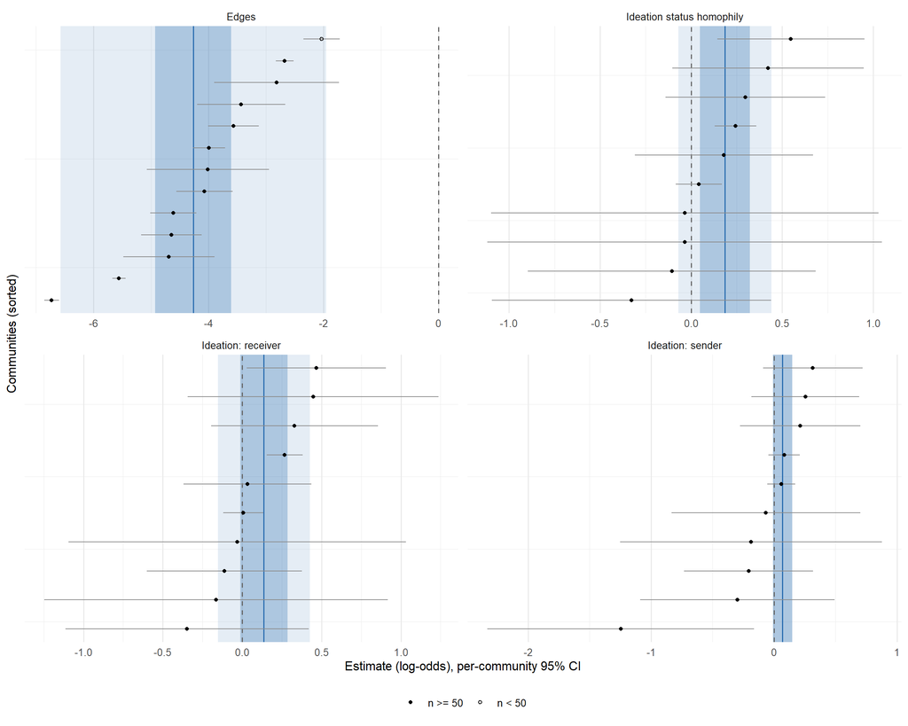

| Term | k | Coverage | I² (%) | Q p | T² p | LOO shift (SE) | Most influential | Small-comm. shift | Attrition shift | SE>5 shift | Size p | Integrated z | AIC FE / RE | Verdict |
| --- | --- | --- | --- | --- | --- | --- | --- | --- | --- | --- | --- | --- | --- | --- |
| Edges | 12 | 75% | 99 | 0 | 0 | 0.68 | 477 | 0.54 | 0.86 | — | 0.000 | — | 1791 / 40 | caution |
| Ideation: receiver | 10 | 62% | 41 | 0.08 | 0.0011 | 1.10 | 477 | — | 0.79 | — | 0.902 | — | 7 / 5 | caution |
| Ideation status homophily | 10 | 62% | 34 | 0.19 | 0.00068 | 0.90 | 477 | — | 0.98 | — | 0.403 | — | 4 / 4 | caution |
| Ideation: sender | 10 | 62% | 0 | 0.32 | 0.2 | 0.24 | 428 | — | 0.06 | — | 0.796 | — | 2 / 4 | caution |

**Communities not pooled (3)**

| Community | Nodes | Status | Reason | Method |
| --- | --- | --- | --- | --- |
| 401 | 45 | degenerate |  | Stochastic-Approximation |
| 402 | 61 | degenerate |  | Stochastic-Approximation |
| 463 | 43 | degenerate |  | Stochastic-Approximation |

#### m14c

Each point is one community’s estimate with its 95% CI (open circles: small communities, n < 50). The blue line is the pooled estimate; the dark band its 95% CI and the light band the 95% prediction interval.

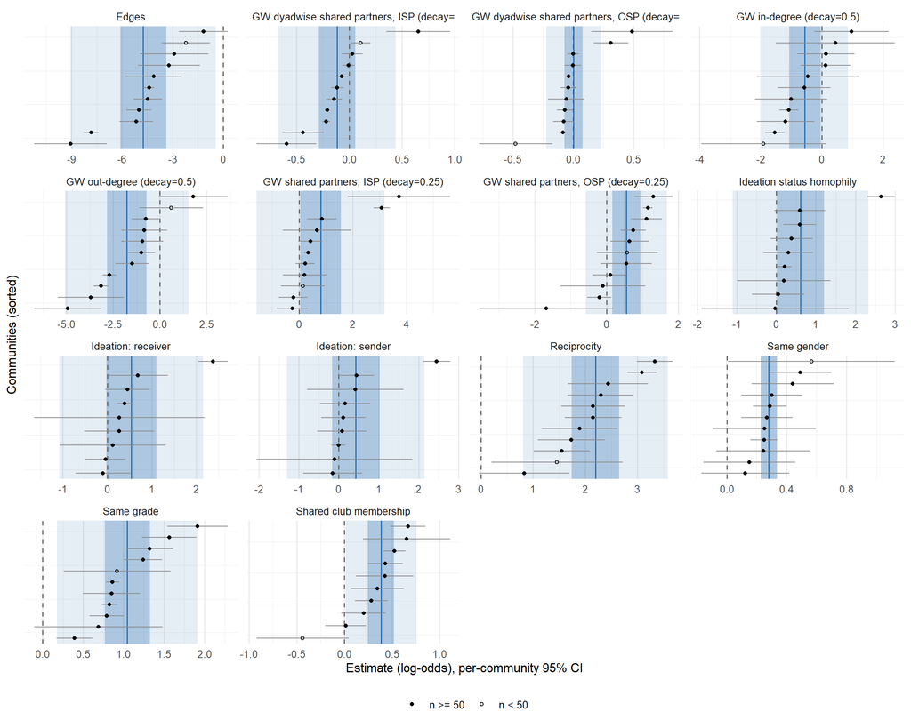

| Term | k | Coverage | I² (%) | Q p | T² p | LOO shift (SE) | Most influential | Small-comm. shift | Attrition shift | SE>5 shift | Size p | Integrated z | AIC FE / RE | Verdict |
| --- | --- | --- | --- | --- | --- | --- | --- | --- | --- | --- | --- | --- | --- | --- |
| Shared club membership | 9 | 56% | 75 | 0.00014 | 7.4e-35 | 0.71 | 407 | 0.72 | 0.58 | — | 0.059 | — | 10 / 1 | poor |
| Edges | 10 | 62% | 97 | 1.2e-41 | 0 | 0.57 | 475 | 0.33 | 0.56 | — | 0.067 | — | 224 / 47 | caution |
| GW dyadwise shared partners, ISP (decay=0.25) | 10 | 62% | 99 | 3.5e-22 | 2.1e-118 | 0.58 | 404 | 0.24 | 0.14 | — | 0.775 | — | 81 / 7 | caution |
| GW dyadwise shared partners, OSP (decay=0.25) | 10 | 62% | 96 | 2.9e-07 | 5.5e-17 | 1.18 | 408 | 0.42 | 0.40 | — | 0.404 | — | 2 / -6 | caution |
| GW shared partners, ISP (decay=0.25) | 10 | 62% | 97 | 1.3e-57 | 6e-87 | 1.23 | 477 | 0.17 | 1.23 | — | 0.108 | — | 287 / 36 | caution |
| GW shared partners, OSP (decay=0.25) | 10 | 62% | 88 | 9.8e-14 | 4.2e-74 | 0.74 | 477 | 0.04 | 0.74 | — | 0.981 | — | 75 / 25 | caution |
| GW in-degree (decay=0.5) | 10 | 62% | 79 | 1.7e-05 | 7.9e-28 | 0.64 | 408 | 0.23 | 0.56 | — | 0.018 | — | 42 / 28 | caution |
| GW out-degree (decay=0.5) | 10 | 62% | 95 | 1.5e-16 | 9.2e-113 | 0.56 | 404 | 0.36 | 0.22 | — | 0.382 | — | 101 / 43 | caution |
| Reciprocity | 10 | 62% | 86 | 8.2e-13 | 1.8e-233 | 0.58 | 408 | 0.18 | 0.57 | — | 0.000 | — | 72 / 25 | caution |
| Ideation: receiver | 9 | 56% | 92 | 3.2e-24 | 2e-43 | 0.82 | 477 | — | 0.82 | — | 0.008 | — | 127 / 25 | poor |
| Same gender | 10 | 62% | 0 | 0.57 | 4.3e-19 | 0.65 | 477 | 0.10 | 0.65 | — | 0.565 | — | -16 / -14 | caution |
| Same grade | 10 | 62% | 95 | 2.3e-14 | 1.3e-245 | 0.65 | 404 | 0.06 | 0.17 | — | 0.760 | — | 63 / 16 | caution |
| Ideation status homophily | 9 | 56% | 92 | 4.9e-30 | 8.6e-48 | 1.02 | 477 | — | 1.02 | — | 0.013 | — | 155 / 26 | poor |
| Ideation: sender | 9 | 56% | 92 | 2.9e-31 | 7.3e-39 | 1.14 | 477 | — | 1.14 | — | 0.021 | — | 161 / 26 | poor |

**Communities not pooled (3)**

| Community | Nodes | Status | Reason | Method |
| --- | --- | --- | --- | --- |
| 401 | 45 | degenerate |  | Stochastic-Approximation |
| 403 | 123 | degenerate |  | Stochastic-Approximation |
| 436 | 53 | degenerate |  | Stochastic-Approximation |

#### m14d

Each point is one community’s estimate with its 95% CI (open circles: small communities, n < 50). The blue line is the pooled estimate; the dark band its 95% CI and the light band the 95% prediction interval.

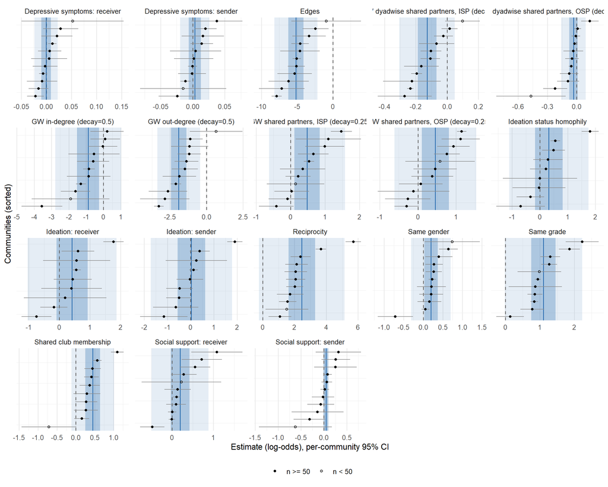

| Term | k | Coverage | I² (%) | Q p | T² p | LOO shift (SE) | Most influential | Small-comm. shift | Attrition shift | SE>5 shift | Size p | Integrated z | AIC FE / RE | Verdict |
| --- | --- | --- | --- | --- | --- | --- | --- | --- | --- | --- | --- | --- | --- | --- |
| Shared club membership | 9 | 56% | 87 | 6.8e-12 | 4.7e-61 | 0.75 | 477 | 0.65 | 0.75 | — | 0.000 | — | 49 / 6 | poor |
| Edges | 10 | 62% | 83 | 5.7e-10 | 2e-200 | 0.76 | 477 | 0.28 | 0.76 | — | 0.174 | — | 79 / 42 | caution |
| GW dyadwise shared partners, ISP (decay=0.25) | 10 | 62% | 91 | 5.8e-23 | 7.2e-142 | 0.60 | 406 | 0.59 | 0.29 | — | 0.165 | — | 81 / -15 | caution |
| GW dyadwise shared partners, OSP (decay=0.25) | 10 | 62% | 89 | 4.8e-05 | 1.3e-08 | 0.59 | 404 | 0.33 | 0.10 | — | 0.908 | — | -14 / -19 | caution |
| GW shared partners, ISP (decay=0.25) | 10 | 62% | 88 | 1.1e-10 | 1.2e-30 | 0.72 | 477 | 0.12 | 0.72 | — | 0.086 | — | 57 / 21 | caution |
| GW shared partners, OSP (decay=0.25) | 10 | 62% | 88 | 3.7e-18 | 2.7e-79 | 0.60 | 477 | 0.06 | 0.60 | — | 0.977 | — | 94 / 20 | caution |
| GW in-degree (decay=0.5) | 10 | 62% | 88 | 1.5e-06 | 2.4e-28 | 0.67 | 404 | 0.14 | 0.17 | — | 0.842 | — | 46 / 33 | caution |
| GW out-degree (decay=0.5) | 10 | 62% | 80 | 5.9e-10 | 5.1e-119 | 0.84 | 458 | 0.55 | 0.13 | — | 0.103 | — | 65 / 27 | caution |
| Reciprocity | 10 | 62% | 95 | 2.6e-45 | 3.8e-273 | 0.81 | 477 | 0.17 | 0.81 | — | 0.000 | — | 230 / 37 | caution |
| Depressive symptoms: receiver | 10 | 62% | 62 | 0.0033 | 0.0059 | 0.72 | 477 | 0.09 | 0.72 | — | 0.818 | — | -46 / -52 | caution |
| Ideation: receiver | 9 | 56% | 91 | 5.6e-16 | 8.5e-34 | 0.83 | 477 | — | 0.83 | — | 0.026 | — | 85 / 23 | poor |
| Social support: receiver | 10 | 62% | 94 | 1.2e-06 | 4.4e-07 | 0.61 | 426 | 0.01 | 0.29 | — | 0.163 | — | 22 / 13 | caution |
| Same gender | 10 | 62% | 86 | 1e-05 | 1.5e-13 | 0.67 | 404 | 0.24 | 0.20 | — | 0.866 | — | 17 / 8 | caution |
| Same grade | 10 | 62% | 96 | 1.6e-16 | 1.8e-241 | 0.61 | 404 | 0.05 | 0.18 | — | 0.860 | — | 76 / 21 | caution |
| Ideation status homophily | 9 | 56% | 91 | 8.6e-16 | 1.8e-35 | 0.63 | 477 | — | 0.63 | — | 0.000 | — | 84 / 23 | poor |
| Depressive symptoms: sender | 10 | 62% | 63 | 0.0072 | 0.011 | 0.62 | 407 | 0.08 | 0.24 | — | 0.144 | — | -48 / -51 | caution |
| Ideation: sender | 9 | 56% | 93 | 9.5e-23 | 6.1e-27 | 0.66 | 477 | — | 0.66 | — | 0.001 | — | 119 / 26 | poor |
| Social support: sender | 10 | 62% | 0 | 0.34 | 0.21 | 0.59 | 477 | 0.11 | 0.59 | — | 0.773 | — | -11 / -9 | caution |

**Communities not pooled (3)**

| Community | Nodes | Status | Reason | Method |
| --- | --- | --- | --- | --- |
| 401 | 45 | degenerate |  | Stochastic-Approximation |
| 403 | 123 | failed | Matrix x has negative elements on the diagonal. |  |
| 436 | 53 | degenerate |  | Stochastic-Approximation |

## Fit & Convergence

Fit status by model (communities)

| Model | Part | degenerate | fit | failed |
| --- | --- | --- | --- | --- |
| m14a | ergm | 3 | 13 | 0 |
| m14c | ergm | 3 | 13 | 0 |
| m14d | ergm | 2 | 13 | 1 |

**Terms dropped in some communities** (attribute had no usable variation there; those communities do not contribute to that term’s pooled estimate):

| Model | Term [reason] | Communities |
| --- | --- | --- |
| m14a | nodeicov(“ideation_binary_w1”) [minority n = 2 < 5] | 1 |
| m14a | nodeicov(“ideation_binary_w1”) [minority n = 3 < 5] | 1 |
| m14a | nodeicov(“ideation_binary_w1”) [minority n = 4 < 5] | 1 |
| m14a | nodematch(“ideation_binary_w1”) [minority n = 2 < 5] | 1 |
| m14a | nodematch(“ideation_binary_w1”) [minority n = 3 < 5] | 1 |
| m14a | nodematch(“ideation_binary_w1”) [minority n = 4 < 5] | 1 |
| m14a | nodeocov(“ideation_binary_w1”) [minority n = 2 < 5] | 1 |
| m14a | nodeocov(“ideation_binary_w1”) [minority n = 3 < 5] | 1 |
| m14a | nodeocov(“ideation_binary_w1”) [minority n = 4 < 5] | 1 |
| m14c | nodeicov(“ideation_binary_w1”) [minority n = 2 < 5] | 1 |
| m14c | nodeicov(“ideation_binary_w1”) [minority n = 3 < 5] | 1 |
| m14c | nodeicov(“ideation_binary_w1”) [minority n = 4 < 5] | 1 |
| m14c | nodematch(“ideation_binary_w1”) [minority n = 2 < 5] | 1 |
| m14c | nodematch(“ideation_binary_w1”) [minority n = 3 < 5] | 1 |
| m14c | nodematch(“ideation_binary_w1”) [minority n = 4 < 5] | 1 |
| m14c | nodeocov(“ideation_binary_w1”) [minority n = 2 < 5] | 1 |
| m14c | nodeocov(“ideation_binary_w1”) [minority n = 3 < 5] | 1 |
| m14c | nodeocov(“ideation_binary_w1”) [minority n = 4 < 5] | 1 |
| m14d | nodeicov(“ideation_binary_w1”) [minority n = 2 < 5] | 1 |
| m14d | nodeicov(“ideation_binary_w1”) [minority n = 3 < 5] | 1 |
| m14d | nodeicov(“ideation_binary_w1”) [minority n = 4 < 5] | 1 |
| m14d | nodematch(“ideation_binary_w1”) [minority n = 2 < 5] | 1 |
| m14d | nodematch(“ideation_binary_w1”) [minority n = 3 < 5] | 1 |
| m14d | nodematch(“ideation_binary_w1”) [minority n = 4 < 5] | 1 |
| m14d | nodeocov(“ideation_binary_w1”) [minority n = 2 < 5] | 1 |
| m14d | nodeocov(“ideation_binary_w1”) [minority n = 3 < 5] | 1 |
| m14d | nodeocov(“ideation_binary_w1”) [minority n = 4 < 5] | 1 |

**AIC by community** (lower is better; green = best model for that community). Only usable fits are compared, and AIC is comparable across models only for the same community.

| Community | m14a | m14c | m14d |
| --- | --- | --- | --- |
| 402 | — | 747.6 | 737.0 |
| 403 | 1.51e+03 | — | — |
| 404 | 1.68e+03 | 2.44e+04 | 3.03e+03 |
| 405 | 2.64e+03 | 1.82e+03 | 1.83e+03 |
| 406 | 1.52e+03 | 1.63e+03 | 1.88e+03 |
| 407 | 3.73e+03 | 3.09e+03 | 3.08e+03 |
| 408 | 2.35e+03 | 1.33e+04 | 4.51e+03 |
| 415 | 274.4 | 236.5 | 238.4 |
| 426 | 1.13e+03 | 913.1 | 1.15e+03 |
| 428 | 3.73e+03 | 2.92e+03 | 3.23e+03 |
| 436 | 502.0 | — | — |
| 458 | 4.25e+04 | 3.25e+04 | 3.26e+04 |
| 463 | — | 1.74e+03 | 381.8 |
| 475 | 1.27e+03 | 2.71e+03 | 2.16e+03 |
| 477 | 5.70e+04 | 5.72e+04 | 5.06e+04 |

| Best model | Communities |
| --- | --- |
| m14a | 6 |
| m14c | 5 |
| m14d | 4 |

## Goodness of Fit

For each fitted community, simulated networks from the model are compared with the observed network on in-degree, out-degree, shared partners, geodesic distance and the model terms. The table shows the share of communities where at least one category of that statistic fits poorly (MC p < 0.05). The per-category values are in `ergm_gof.csv`.

Share of communities with poor fit, by GOF statistic

| Model | dist | espart | ideg | model | odeg |
| --- | --- | --- | --- | --- | --- |
| m14a | 75% of 16 | 81% of 16 | 81% of 16 | 0% of 16 | 75% of 16 |
| m14c | 81% of 16 | 62% of 16 | 75% of 16 | 69% of 16 | 69% of 16 |
| m14d | 87% of 15 | 67% of 15 | 67% of 15 | 73% of 15 | 73% of 15 |

Each community’s GOF plots are in **By Community** (boxes = networks simulated from the fitted model; line = observed network; good fit = the line stays inside the boxes). `GOF_IMAGE_MODELS` at the top of this file chooses which models’ plots are embedded.

## Collinearity Flags

Coefficient pairs whose estimates are correlated at |r| ≥ 0.7 (from each fit’s covariance matrix). The model cannot cleanly separate those two effects in that community; treat both coefficients with caution.

Flagged pairs (number of communities)

| Model | Term 1 | Term 2 | Communities |
| --- | --- | --- | --- |
| m14a | Edges | Ideation status homophily | 13 |
| m14a | Edges | Ideation: receiver | 10 |
| m14a | Edges | Ideation: sender | 8 |
| m14a | Ideation status homophily | Ideation: receiver | 8 |
| m14c | GW in-degree (decay=0.5) | GW dyadwise shared partners, OSP (decay=0.25) | 8 |
| m14c | GW out-degree (decay=0.5) | GW dyadwise shared partners, ISP (decay=0.25) | 8 |
| m14c | GW shared partners, OSP (decay=0.25) | GW shared partners, ISP (decay=0.25) | 8 |
| m14d | GW shared partners, OSP (decay=0.25) | GW shared partners, ISP (decay=0.25) | 8 |
| m14a | Ideation status homophily | Ideation: sender | 7 |
| m14c | Ideation status homophily | Ideation: receiver | 6 |
| m14c | Ideation status homophily | Ideation: sender | 6 |
| m14d | GW out-degree (decay=0.5) | GW dyadwise shared partners, ISP (decay=0.25) | 6 |
| m14d | Ideation status homophily | Ideation: receiver | 6 |
| m14d | GW in-degree (decay=0.5) | GW dyadwise shared partners, OSP (decay=0.25) | 5 |
| m14c | Ideation: receiver | Ideation: sender | 4 |
| m14a | Ideation: receiver | Ideation: sender | 3 |
| m14d | Ideation status homophily | Ideation: sender | 3 |
| m14c | Edges | Ideation status homophily | 2 |
| m14d | Ideation: receiver | Ideation: sender | 2 |
| m14c | Edges | GW dyadwise shared partners, ISP (decay=0.25) | 1 |
| m14c | Edges | GW out-degree (decay=0.5) | 1 |
| m14c | Edges | GW shared partners, ISP (decay=0.25) | 1 |
| m14c | Edges | Ideation: receiver | 1 |
| m14c | Edges | Same grade | 1 |
| m14c | GW in-degree (decay=0.5) | GW dyadwise shared partners, ISP (decay=0.25) | 1 |
| m14c | GW out-degree (decay=0.5) | GW dyadwise shared partners, OSP (decay=0.25) | 1 |
| m14c | Reciprocity | GW dyadwise shared partners, OSP (decay=0.25) | 1 |
| m14c | Reciprocity | GW in-degree (decay=0.5) | 1 |

## Robustness Across Specifications

How stable is each term’s estimate as models grow? Each line follows one community across the models that contain the term (usable fits only).

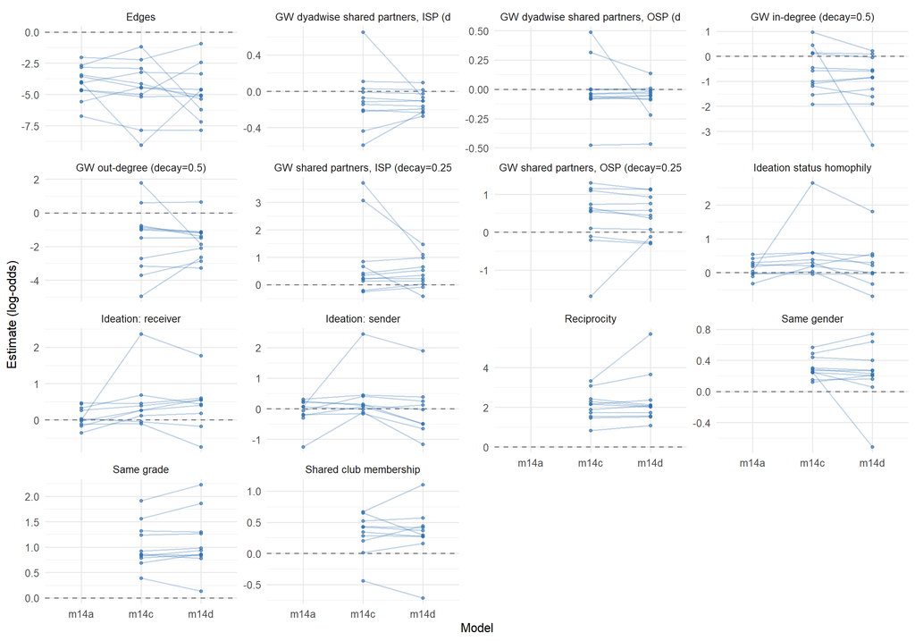

# 3. STERGMs — Directed Network Change Between Waves

**Show STERGM models:** m7 step 1 m7 step 2 m7 step 3 m7 step 3

Separable temporal ERGMs (CMLE) model arc **formation** and **dissolution** between waves 1 and 2 as separate sub-models, with wave 1 covariates. **Formation: estimate > 0 = a new arc is more likely to form. Dissolution: tergm ≥ 4.0 estimates this sub-model as persistence (`Persist()` terms), so estimate > 0 = an existing arc is more likely to persist (less likely to dissolve), and < 0 = more likely to dissolve.** Models with a blank formation or dissolution formula in `config/stergm_model_desc.csv` are one-sided build-up steps and only appear in that sub-model’s tables. Pooling and trust checks are run separately for each sub-model.

## Formation — Pooled

Pooled formation estimates across communities

| Term | m7 step 1 | m7 step 2 | m7 step 3 | m7 step 3 |
| --- | --- | --- | --- | --- |
| Edges | -4.846*** (0.387) [-7.49, -2.20] k = 12 | -4.645*** (0.484) [-7.56, -1.73] k = 9 | -7.144*** (0.721) [-10.11, -4.18] k = 6 | -7.477*** (0.758) [-11.10, -3.85] k = 7 |
| Ideation status homophily | 0.174<sup>+</sup> (0.105) [-0.22, 0.56] k = 10 | -0.558 (0.711) [-4.43, 3.32] k = 7 | 0.299** (0.114) [0.04, 0.56] k = 5 | 0.068 (0.228) [-0.97, 1.11] k = 6 |
| Ideation: receiver | -0.072 (0.071) [-0.21, 0.07] k = 10 | -0.135 (0.268) [-1.43, 1.16] k = 7 | 0.028 (0.114) [-0.20, 0.25] k = 5 | 0.817 (0.735) [-2.94, 4.57] k = 6 |
| Ideation: sender | 0.126 (0.148) [-0.58, 0.83] k = 10 | -0.367 (0.450) [-2.74, 2.01] k = 7 | 0.205<sup>+</sup> (0.109) [-0.01, 0.42] k = 5 | 1.051 (0.790) [-2.99, 5.09] k = 6 |
| Reciprocity | — | 2.953*** (0.226) [1.58, 4.33] k = 10 | 3.344*** (0.373) [1.46, 5.23] k = 6 | 3.893*** (0.683) [0.14, 7.65] k = 7 |
| Shared club membership | — | 0.619*** (0.080) [0.26, 0.98] k = 9 | 0.569*** (0.097) [0.18, 0.96] k = 6 | 1.483 (0.953) [-3.79, 6.75] k = 7 |
| Same gender | — | 0.275** (0.102) [-0.28, 0.83] k = 10 | 0.154** (0.059) [-0.02, 0.33] k = 6 | -0.443 (0.555) [-3.51, 2.62] k = 7 |
| Depressive symptoms: receiver | — | — | 0.009 (0.012) [-0.05, 0.06] k = 6 | 0.016 (0.026) [-0.11, 0.14] k = 7 |
| Depressive symptoms: sender | — | — | -0.001 (0.004) [-0.01, 0.01] k = 6 | -0.102 (0.123) [-0.77, 0.57] k = 7 |
| Social support: receiver | — | — | 0.267* (0.125) [-0.26, 0.80] k = 6 | 0.153 (0.135) [-0.51, 0.81] k = 7 |
| Social support: sender | — | — | 0.145 (0.116) [-0.33, 0.62] k = 6 | 0.531 (0.329) [-1.25, 2.32] k = 7 |
| Depressive symptoms squared: receiver | — | — | — | -0.000 (0.001) [-0.01, 0.01] k = 7 |
| Depressive symptoms squared: sender | — | — | — | 0.002 (0.003) [-0.01, 0.02] k = 7 |
| Communities fit | 14 | 14 | 10 | 12 |
| of which small, not pooled | 2 | 2 | 2 | 2 |
| Failed / degenerate / timed out | 1 | 1 | 5 | 3 |
| Too small / too few events | 1 | 1 | 1 | 1 |
| With terms dropped | 3 | 3 | 3 | 3 |

## Dissolution (Persistence) — Pooled

Pooled persistence estimates across communities (> 0 = arc more likely to persist)

| Term | m7 step 1 | m7 step 2 | m7 step 3 | m7 step 3 |
| --- | --- | --- | --- | --- |
| Edges | -0.602* (0.272) [-2.09, 0.89] k = 10 | -1.651*** (0.118) [-1.88, -1.42] k = 6 | -3.524*** (0.929) [-6.82, -0.23] k = 6 | -3.196*** (0.854) [-6.11, -0.28] k = 6 |
| Ideation status homophily | 0.080 (0.094) [-0.10, 0.26] k = 8 | -0.042 (0.295) [-1.06, 0.97] k = 5 | 0.015 (0.388) [-1.35, 1.38] k = 5 | 0.038 (0.357) [-1.19, 1.26] k = 5 |
| Ideation: receiver | -0.041 (0.094) [-0.23, 0.14] k = 8 | -0.066 (0.130) [-0.32, 0.19] k = 5 | -0.032 (0.134) [-0.29, 0.23] k = 5 | 0.011 (0.137) [-0.26, 0.28] k = 5 |
| Ideation: sender | -0.028 (0.094) [-0.21, 0.16] k = 7 | -0.359 (0.346) [-1.63, 0.91] k = 5 | -0.048 (0.329) [-1.11, 1.02] k = 5 | -0.125 (0.359) [-1.33, 1.08] k = 5 |
| Reciprocity | — | 1.734*** (0.151) [1.28, 2.18] k = 6 | 1.697*** (0.167) [1.16, 2.23] k = 6 | 1.639*** (0.153) [1.17, 2.11] k = 7 |
| Shared club membership | — | 0.367*** (0.071) [0.23, 0.51] k = 5 | 0.179* (0.081) [0.02, 0.34] k = 5 | 0.307*** (0.072) [0.16, 0.45] k = 6 |
| Same gender | — | 0.623*** (0.072) [0.48, 0.76] k = 6 | 0.713*** (0.074) [0.57, 0.86] k = 6 | 0.686*** (0.073) [0.54, 0.83] k = 7 |
| Depressive symptoms: receiver | — | — | -0.012 (0.010) [-0.04, 0.02] k = 6 | -0.012 (0.010) [-0.04, 0.02] k = 7 |
| Depressive symptoms: sender | — | — | 0.009 (0.015) [-0.05, 0.07] k = 6 | 0.006 (0.010) [-0.02, 0.04] k = 7 |
| Social support: receiver | — | — | 0.188* (0.081) [0.03, 0.35] k = 6 | 0.103 (0.102) [-0.18, 0.38] k = 7 |
| Social support: sender | — | — | 0.478 (0.297) [-0.89, 1.84] k = 6 | 0.396 (0.260) [-0.81, 1.61] k = 7 |
| Communities fit | 11 | 8 | 8 | 9 |
| of which small, not pooled | 1 | 1 | 1 | 1 |
| Failed / degenerate / timed out | 4 | 7 | 7 | 6 |
| Too small / too few events | 1 | 1 | 1 | 1 |
| With terms dropped | 3 | 3 | 3 | 3 |

### Do community characteristics explain the differences?

| Model | Part | Term | Moderator | Estimate | SE | p | R² (%) | k |
| --- | --- | --- | --- | --- | --- | --- | --- | --- |
| m7f3d3 | dissolution | Shared club membership | log(n_nodes) | 0.006 | 0.120 | 0.96 | 0 | 5 |
| m7f3d3 | dissolution | Shared club membership | ideation_prev_w1 | -5.060 | 9.245 | 0.58 | 0 | 5 |
| m7f3d3 | dissolution | Edges | log(n_nodes) | 1.974 | 0.911 | 0.03 | 100 | 6 |
| m7f3d3 | dissolution | Edges | ideation_prev_w1 | -4.52e+01 | 4.80e+01 | 0.35 | 100 | 6 |
| m7f3d3 | dissolution | Reciprocity | log(n_nodes) | 0.389 | 0.167 | 0.02 | 100 | 6 |
| m7f3d3 | dissolution | Reciprocity | ideation_prev_w1 | -1.86e+01 | 8.685 | 0.032 | 100 | 6 |
| m7f3d3 | dissolution | Depressive symptoms: receiver | log(n_nodes) | 0.017 | 0.011 | 0.11 | 100 | 6 |
| m7f3d3 | dissolution | Depressive symptoms: receiver | ideation_prev_w1 | -0.397 | 0.568 | 0.48 | 100 | 6 |
| m7f3d3 | dissolution | Ideation: receiver | log(n_nodes) | -0.216 | 0.521 | 0.68 | 0 | 5 |
| m7f3d3 | dissolution | Ideation: receiver | ideation_prev_w1 | -2.325 | 3.99e+01 | 0.95 | 0 | 5 |
| m7f3d3 | dissolution | Social support: receiver | log(n_nodes) | 0.246 | 0.146 | 0.092 | 100 | 6 |
| m7f3d3 | dissolution | Social support: receiver | ideation_prev_w1 | -1.72e+01 | 8.011 | 0.032 | 100 | 6 |
| m7f3d3 | dissolution | Same gender | log(n_nodes) | -0.051 | 0.131 | 0.7 | 0 | 6 |
| m7f3d3 | dissolution | Same gender | ideation_prev_w1 | 3.077 | 6.090 | 0.61 | 0 | 6 |
| m7f3d3 | dissolution | Ideation status homophily | log(n_nodes) | -0.277 | 0.644 | 0.67 | 0 | 5 |
| m7f3d3 | dissolution | Ideation status homophily | ideation_prev_w1 | 7.039 | 4.51e+01 | 0.88 | 0 | 5 |
| m7f3d3 | dissolution | Depressive symptoms: sender | log(n_nodes) | -0.026 | 0.016 | 0.11 | 31 | 6 |
| m7f3d3 | dissolution | Depressive symptoms: sender | ideation_prev_w1 | 0.896 | 0.683 | 0.19 | 31 | 6 |
| m7f3d3 | dissolution | Ideation: sender | log(n_nodes) | 0.237 | 0.714 | 0.74 | 0 | 5 |
| m7f3d3 | dissolution | Ideation: sender | ideation_prev_w1 | -1.66e+01 | 4.92e+01 | 0.74 | 0 | 5 |
| m7f3d3 | dissolution | Social support: sender | log(n_nodes) | -0.661 | 0.240 | 0.0058 | 72 | 6 |
| m7f3d3 | dissolution | Social support: sender | ideation_prev_w1 | 2.49e+01 | 9.639 | 0.0097 | 72 | 6 |
| m7f3d3 | formation | Shared club membership | log(n_nodes) | 0.079 | 0.160 | 0.62 | 0 | 6 |
| m7f3d3 | formation | Shared club membership | ideation_prev_w1 | 0.765 | 4.538 | 0.87 | 0 | 6 |
| m7f3d3 | formation | Edges | log(n_nodes) | 1.432 | 0.819 | 0.08 | 47 | 6 |
| m7f3d3 | formation | Edges | ideation_prev_w1 | -4.64e+01 | 2.44e+01 | 0.057 | 47 | 6 |
| m7f3d3 | formation | Reciprocity | log(n_nodes) | 1.092 | 0.111 | 6.3e-23 | 100 | 6 |
| m7f3d3 | formation | Reciprocity | ideation_prev_w1 | -8.871 | 3.814 | 0.02 | 100 | 6 |
| m7f3d3 | formation | Depressive symptoms: receiver | log(n_nodes) | 0.003 | 0.020 | 0.88 | 0 | 6 |
| m7f3d3 | formation | Depressive symptoms: receiver | ideation_prev_w1 | -0.419 | 0.585 | 0.47 | 0 | 6 |

[output cut: 62 more lines]

## Can the Pooled Results Be Trusted?

Same checks as for the ERGMs (see the ERGM section), applied to each sub-model separately.

Trust verdict: formation

| Term | m7 step 1 | m7 step 2 | m7 step 3 | m7 step 3 |
| --- | --- | --- | --- | --- |
| Edges | caution large between-community variation; depends on high-attrition communities; depends on community size | poor few communities pooled; large between-community variation | poor few communities pooled | poor few communities pooled; large between-community variation |
| Ideation status homophily | caution few communities pooled; depends on community size | poor few communities pooled; large between-community variation; driven by one community; depends on high-attrition communities | poor few communities pooled; driven by one community; depends on small communities | poor few communities pooled; large between-community variation; depends on community size |
| Ideation: receiver | caution few communities pooled | poor few communities pooled; large between-community variation | poor few communities pooled; depends on small communities | poor few communities pooled; large between-community variation; driven by one community; depends on high-attrition communities |
| Ideation: sender | caution few communities pooled | poor few communities pooled; large between-community variation; driven by one community; depends on high-attrition communities | poor few communities pooled; driven by one community | poor few communities pooled; large between-community variation; driven by one community; depends on high-attrition communities |
| Reciprocity | — | caution few communities pooled; large between-community variation; depends on community size | poor few communities pooled; large between-community variation; depends on community size | poor few communities pooled; large between-community variation; depends on community size |
| Shared club membership | — | poor few communities pooled; depends on small communities | poor few communities pooled; depends on small communities | poor few communities pooled; large between-community variation; depends on community size |
| Same gender | — | caution few communities pooled; large between-community variation; driven by one community; depends on high-attrition communities | poor few communities pooled | poor few communities pooled; large between-community variation; driven by one community; depends on high-attrition communities; depends on community size |
| Depressive symptoms: receiver | — | — | poor few communities pooled; large between-community variation | poor few communities pooled; large between-community variation |
| Depressive symptoms: sender | — | — | poor few communities pooled; driven by one community | poor few communities pooled; large between-community variation; driven by one community; depends on high-attrition communities; depends on community size |
| Social support: receiver | — | — | poor few communities pooled; driven by one community | poor few communities pooled; large between-community variation; depends on community size |
| Social support: sender | — | — | poor few communities pooled; driven by one community; depends on community size | poor few communities pooled; large between-community variation; driven by one community; depends on high-attrition communities |
| Depressive symptoms squared: receiver | — | — | — | poor few communities pooled; large between-community variation |
| Depressive symptoms squared: sender | — | — | — | poor few communities pooled; large between-community variation; driven by one community; depends on high-attrition communities; depends on community size |
| Terms rated ok | 0 | 0 | 0 | 0 |
| Terms rated caution | 4 | 2 | 0 | 0 |
| Terms rated poor | 0 | 5 | 11 | 13 |

Trust verdict: dissolution (persistence)

| Term | m7 step 1 | m7 step 2 | m7 step 3 | m7 step 3 |
| --- | --- | --- | --- | --- |
| Edges | caution few communities pooled; large between-community variation; driven by one community | poor few communities pooled; driven by one community; depends on small communities | poor few communities pooled; driven by one community; depends on community size | poor few communities pooled; driven by one community; depends on community size |
| Ideation status homophily | poor few communities pooled | poor few communities pooled | poor few communities pooled | poor few communities pooled |
| Ideation: receiver | poor few communities pooled | poor few communities pooled | poor few communities pooled; driven by one community | poor few communities pooled |
| Ideation: sender | poor few communities pooled; depends on high-attrition communities | poor few communities pooled | poor few communities pooled | poor few communities pooled |
| Reciprocity | — | poor few communities pooled | poor few communities pooled | poor few communities pooled |
| Shared club membership | — | poor few communities pooled | poor few communities pooled | poor few communities pooled |
| Same gender | — | poor few communities pooled | poor few communities pooled | poor few communities pooled |
| Depressive symptoms: receiver | — | — | poor few communities pooled; driven by one community | poor few communities pooled; driven by one community |
| Depressive symptoms: sender | — | — | poor few communities pooled | poor few communities pooled |
| Social support: receiver | — | — | poor few communities pooled | poor few communities pooled |
| Social support: sender | — | — | poor few communities pooled; large between-community variation | poor few communities pooled; large between-community variation |
| Terms rated ok | 0 | 0 | 0 | 0 |
| Terms rated caution | 1 | 0 | 0 | 0 |
| Terms rated poor | 3 | 7 | 11 | 11 |

Do pooled communities differ from the rest?

| Model | Part | Pooled | Of | Median n (pooled) | Median n (others) | Size differs p | Density differs p | Ideation prev. differs p |
| --- | --- | --- | --- | --- | --- | --- | --- | --- |
| m7f1d1 | dissolution | 10 | 16 | 101 | 50.0 | 0.12 | 0.71 | 0.31 |
| m7f1d1 | formation | 12 | 16 | 101 | 44.0 | 0.03 | 0.86 | 0.1 |
| m7f2d2 | dissolution | 7 | 16 | 111 | 61.0 | 0.21 | 0.68 | 0.25 |
| m7f2d2 | formation | 12 | 16 | 95 | 44.0 | 0.17 | 0.68 | 0.6 |
| m7f3d3 | dissolution | 7 | 16 | 91 | 61.0 | 0.54 | 0.3 | 0.042 |
| m7f3d3 | formation | 8 | 16 | 101 | 53.5 | 0.16 | 0.88 | 0.38 |
| m7f4d3 | dissolution | 8 | 16 | 87 | 76.0 | 0.65 | 0.16 | 0.028 |
| m7f4d3 | formation | 10 | 16 | 105 | 48.5 | 0.011 | 0.26 | 0.49 |

### Details by Model

#### m7 step 1 — formation

Each point is one community’s estimate with its 95% CI (open circles: small communities, n < 50). The blue line is the pooled estimate; the dark band its 95% CI and the light band the 95% prediction interval.

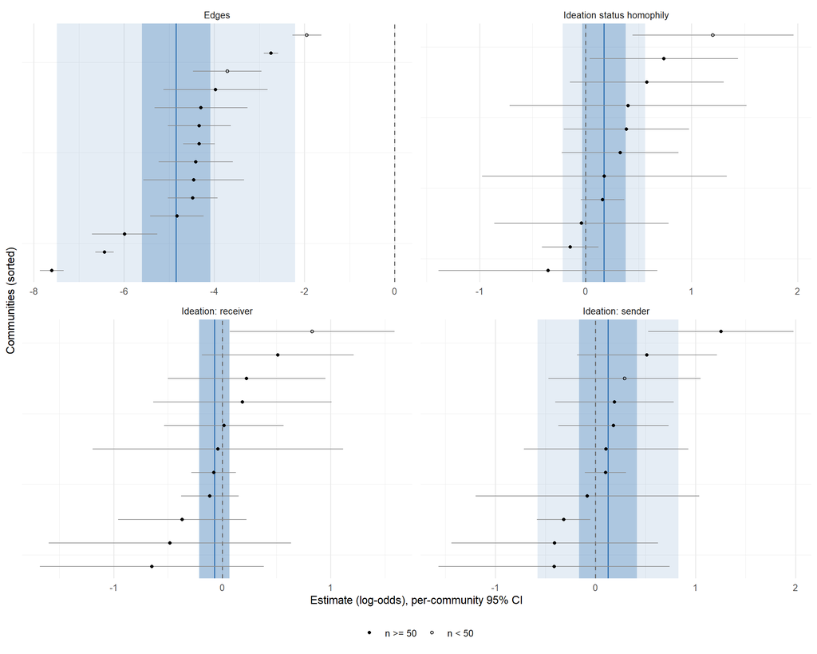

| Term | k | Coverage | I² (%) | Q p | T² p | LOO shift (SE) | Most influential | Small-comm. shift | Attrition shift | SE>5 shift | Size p | Integrated z | AIC FE / RE | Verdict |
| --- | --- | --- | --- | --- | --- | --- | --- | --- | --- | --- | --- | --- | --- | --- |
| Edges | 12 | 75% | 98 | 1.8e-281 | 0 | 0.68 | 477 | 0.78 | 1.04 | — | 0.000 | — | 1336 / 44 | caution |
| Ideation: receiver | 10 | 62% | 0 | 0.68 | 0.67 | 0.34 | 402 | 0.41 | 0.01 | — | 0.444 | — | 4 / 6 | caution |
| Ideation status homophily | 10 | 62% | 31 | 0.27 | 0.16 | 0.52 | 477 | 0.95 | 0.34 | — | 0.019 | — | 9 / 10 | caution |
| Ideation: sender | 10 | 62% | 63 | 0.0099 | 0.015 | 0.83 | 403 | 0.07 | 0.11 | — | 0.118 | — | 19 / 17 | caution |

**Communities not pooled (2)**

| Community | Nodes | Status | Reason | Method |
| --- | --- | --- | --- | --- |
| 401 | 45 | too few events | formed = 40, dissolved = 8 (minimum 10) |  |
| 404 | 99 | degenerate |  | Stochastic-Approximation |

#### m7 step 2 — formation

Each point is one community’s estimate with its 95% CI (open circles: small communities, n < 50). The blue line is the pooled estimate; the dark band its 95% CI and the light band the 95% prediction interval.

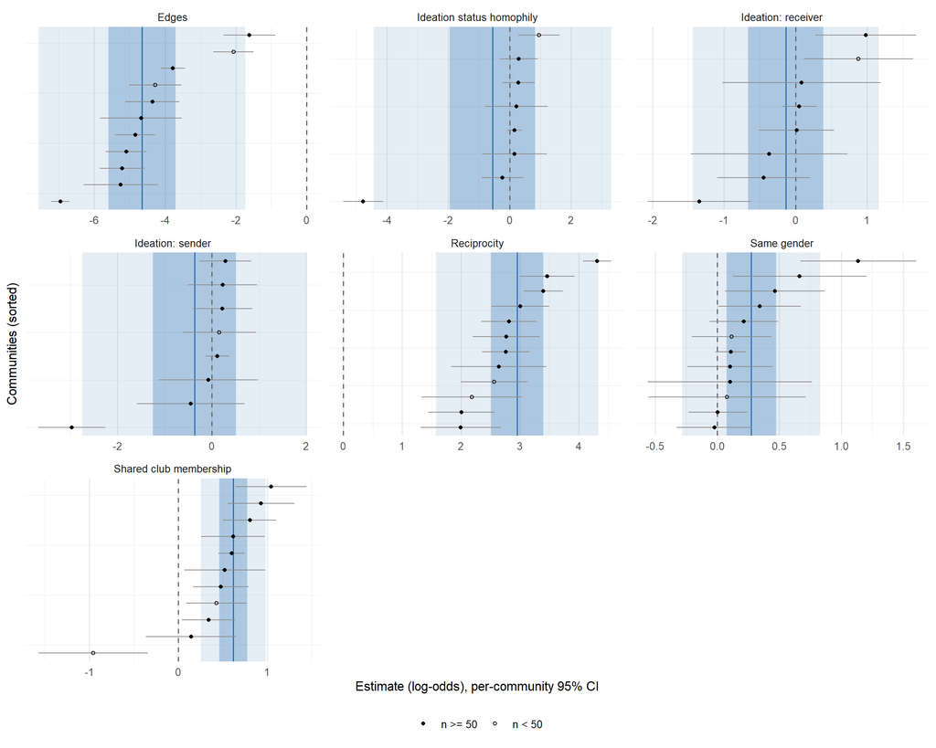

| Term | k | Coverage | I² (%) | Q p | T² p | LOO shift (SE) | Most influential | Small-comm. shift | Attrition shift | SE>5 shift | Size p | Integrated z | AIC FE / RE | Verdict |
| --- | --- | --- | --- | --- | --- | --- | --- | --- | --- | --- | --- | --- | --- | --- |
| Shared club membership | 9 | 56% | 53 | 0.039 | 2.3e-32 | 0.49 | 402 | 1.63 | 0.10 | — | 0.882 | — | 3 / 4 | poor |
| Edges | 9 | 56% | 96 | 8.2e-71 | 0 | 0.80 | 403 | 0.57 | 0.80 | — | 0.104 | — | 348 / 35 | poor |
| Reciprocity | 10 | 62% | 90 | 5e-22 | 0 | 0.67 | 458 | 0.37 | 0.47 | — | 0.001 | — | 114 / 24 | caution |
| Ideation: receiver | 7 | 44% | 81 | 0.00071 | 0.0015 | 0.77 | 403 | 0.46 | 0.77 | — | 0.782 | — | 23 / 18 | poor |
| Same gender | 10 | 62% | 76 | 0.0012 | 3.9e-06 | 1.31 | 403 | 0.31 | 1.31 | — | 0.486 | — | 13 / 10 | caution |
| Ideation status homophily | 7 | 44% | 98 | 7.1e-42 | 3e-42 | 1.01 | 403 | 0.27 | 1.01 | — | 0.914 | — | 205 / 32 | poor |
| Ideation: sender | 7 | 44% | 93 | 3.3e-13 | 7.8e-13 | 1.11 | 403 | 0.15 | 1.11 | — | 0.835 | — | 70 / 25 | poor |

**Communities not pooled (2)**

| Community | Nodes | Status | Reason | Method |
| --- | --- | --- | --- | --- |
| 401 | 45 | too few events | formed = 40, dissolved = 8 (minimum 10) |  |
| 477 | 1721 | degenerate |  | Stochastic-Approximation |

#### m7 step 3 — formation

Each point is one community’s estimate with its 95% CI (open circles: small communities, n < 50). The blue line is the pooled estimate; the dark band its 95% CI and the light band the 95% prediction interval.

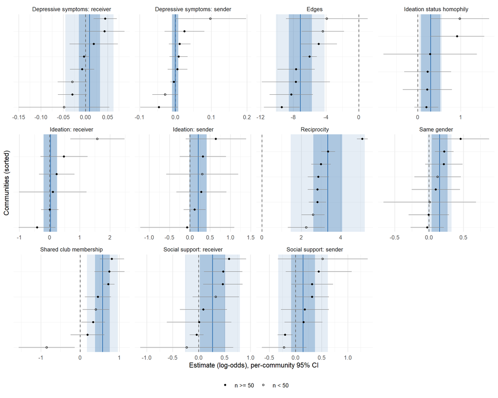

| Term | k | Coverage | I² (%) | Q p | T² p | LOO shift (SE) | Most influential | Small-comm. shift | Attrition shift | SE>5 shift | Size p | Integrated z | AIC FE / RE | Verdict |
| --- | --- | --- | --- | --- | --- | --- | --- | --- | --- | --- | --- | --- | --- | --- |
| Shared club membership | 6 | 38% | 58 | 0.038 | 7.8e-27 | 0.58 | 428 | 1.48 | — | — | 0.325 | — | 2 / 3 | poor |
| Edges | 6 | 38% | 62 | 0.024 | 3.7e-74 | 0.86 | 428 | 0.70 | — | — | 0.795 | — | 27 / 27 | poor |
| Reciprocity | 6 | 38% | 95 | 4.1e-30 | 0 | 0.90 | 458 | 0.55 | — | — | 0.000 | — | 142 / 19 | poor |
| Depressive symptoms: receiver | 6 | 38% | 77 | 0.0024 | 0.0047 | 1.00 | 428 | 0.60 | — | — | 0.635 | — | -19 / -22 | poor |
| Ideation: receiver | 5 | 31% | 0 | 0.43 | 0.57 | 0.60 | 428 | 2.18 | — | — | 0.594 | — | 3 / 5 | poor |
| Social support: receiver | 6 | 38% | 68 | 0.0012 | 0.00036 | 1.10 | 458 | 0.14 | — | — | 0.332 | — | 12 / 5 | poor |
| Same gender | 6 | 38% | 20 | 0.26 | 0.0072 | 0.75 | 428 | 0.05 | — | — | 0.883 | — | -4 / -2 | poor |
| Ideation status homophily | 5 | 31% | 6 | 0.37 | 0.04 | 1.01 | 458 | 1.07 | — | — | 0.203 | — | 3 / 5 | poor |
| Depressive symptoms: sender | 6 | 38% | 0 | 0.35 | 0.47 | 1.46 | 458 | 0.18 | — | — | 0.380 | — | -32 / -30 | poor |
| Ideation: sender | 5 | 31% | 0 | 0.71 | 0.34 | 1.29 | 458 | 0.05 | — | — | 0.267 | — | 2 / 4 | poor |
| Social support: sender | 6 | 38% | 62 | 0.0052 | 0.01 | 1.05 | 458 | 0.23 | — | — | 0.000 | — | 9 / 4 | poor |

**Communities not pooled (6)**

| Community | Nodes | Status | Reason | Method |
| --- | --- | --- | --- | --- |
| 401 | 45 | too few events | formed = 40, dissolved = 8 (minimum 10) |  |
| 403 | 123 | degenerate |  | Stochastic-Approximation |
| 404 | 99 | degenerate |  | Stochastic-Approximation |
| 426 | 55 | degenerate |  | Stochastic-Approximation |
| 475 | 52 | degenerate |  | Stochastic-Approximation |
| 477 | 1721 | degenerate |  | Stochastic-Approximation |

#### m7 step 3 — formation

Each point is one community’s estimate with its 95% CI (open circles: small communities, n < 50). The blue line is the pooled estimate; the dark band its 95% CI and the light band the 95% prediction interval.

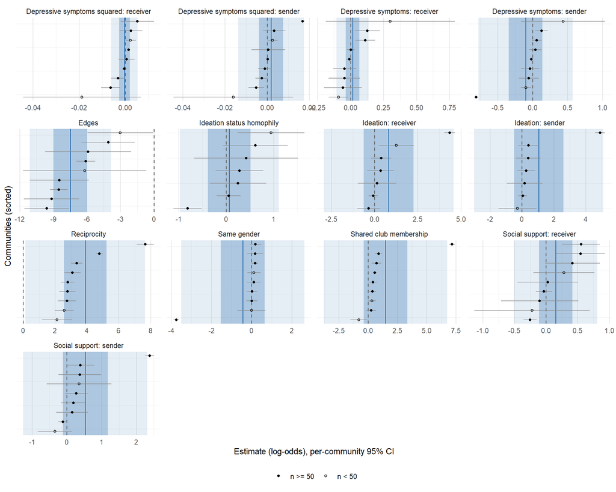

| Term | k | Coverage | I² (%) | Q p | T² p | LOO shift (SE) | Most influential | Small-comm. shift | Attrition shift | SE>5 shift | Size p | Integrated z | AIC FE / RE | Verdict |
| --- | --- | --- | --- | --- | --- | --- | --- | --- | --- | --- | --- | --- | --- | --- |
| Shared club membership | 7 | 44% | 100 | 0 | 0 | 0.99 | 477 | 0.40 | 0.99 | — | 0.013 | — | 2368 / 36 | poor |
| Edges | 7 | 44% | 82 | 1.8e-05 | 4.4e-178 | 0.65 | 436 | 0.69 | 0.31 | — | 0.634 | — | 46 / 33 | poor |
| Reciprocity | 7 | 44% | 99 | 3.8e-67 | 0 | 0.89 | 477 | 0.49 | 0.89 | — | 0.000 | — | 318 / 31 | poor |
| Depressive symptoms: receiver | 7 | 44% | 81 | 0.0053 | 0.0098 | 0.73 | 428 | 0.42 | 0.22 | — | 0.934 | — | -13 / -14 | poor |
| Depressive symptoms squared: receiver | 7 | 44% | 90 | 5.4e-05 | 1.4e-05 | 0.58 | 408 | 0.22 | 0.36 | — | 0.898 | — | -48 / -57 | poor |
| Ideation: receiver | 6 | 38% | 98 | 2.4e-113 | 9.6e-173 | 1.11 | 477 | 0.09 | 1.11 | — | 0.072 | — | 533 / 27 | poor |
| Social support: receiver | 7 | 44% | 88 | 9.7e-08 | 5.1e-08 | 0.68 | 477 | 0.05 | 0.68 | — | 0.036 | — | 32 / 8 | poor |
| Same gender | 7 | 44% | 99 | 0 | 0 | 1.02 | 477 | 0.19 | 1.02 | — | 0.017 | — | 1903 / 28 | poor |
| Ideation status homophily | 6 | 38% | 82 | 5e-06 | 4.6e-06 | 0.54 | 477 | 0.53 | 0.54 | — | 0.003 | — | 29 / 13 | poor |
| Depressive symptoms: sender | 7 | 44% | 99 | 0 | 0 | 1.02 | 477 | 0.26 | 1.02 | — | 0.024 | — | 2082 / 7 | poor |
| Depressive symptoms squared: sender | 7 | 44% | 99 | 9.5e-222 | 0 | 1.00 | 477 | 0.11 | 1.00 | — | 0.049 | — | 964 / -46 | poor |
| Ideation: sender | 6 | 38% | 98 | 9.7e-126 | 1.6e-195 | 1.14 | 477 | 0.22 | 1.14 | — | 0.054 | — | 590 / 28 | poor |
| Social support: sender | 7 | 44% | 98 | 2.6e-172 | 8.8e-295 | 1.15 | 477 | 0.34 | 1.15 | — | 0.092 | — | 801 / 21 | poor |

**Communities not pooled (4)**

| Community | Nodes | Status | Reason | Method |
| --- | --- | --- | --- | --- |
| 401 | 45 | too few events | formed = 40, dissolved = 8 (minimum 10) |  |
| 403 | 123 | degenerate |  | Stochastic-Approximation |
| 426 | 55 | degenerate |  | Stochastic-Approximation |
| 475 | 52 | degenerate |  | Stochastic-Approximation |

#### m7 step 1 — dissolution

Each point is one community’s estimate with its 95% CI (open circles: small communities, n < 50). The blue line is the pooled estimate; the dark band its 95% CI and the light band the 95% prediction interval.

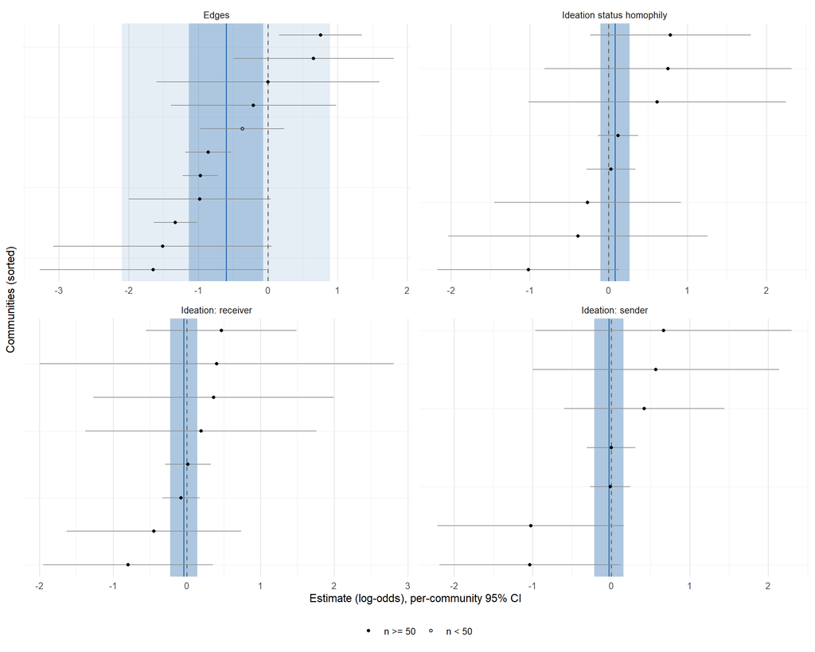

| Term | k | Coverage | I² (%) | Q p | T² p | LOO shift (SE) | Most influential | Small-comm. shift | Attrition shift | SE>5 shift | Size p | Integrated z | AIC FE / RE | Verdict |
| --- | --- | --- | --- | --- | --- | --- | --- | --- | --- | --- | --- | --- | --- | --- |
| Edges | 10 | 62% | 87 | 2.2e-07 | 1.1e-31 | 1.02 | 436 | 0.09 | 0.76 | — | 0.132 | — | 50 / 28 | caution |
| Ideation: receiver | 8 | 50% | 0 | 0.81 | 0.86 | 0.42 | 458 | — | 0.43 | — | 0.882 | — | 9 / 11 | poor |
| Ideation status homophily | 8 | 50% | 0 | 0.4 | 0.43 | 0.47 | 458 | — | 0.19 | — | 0.878 | — | 12 / 14 | poor |
| Ideation: sender | 7 | 44% | 0 | 0.26 | 0.35 | 0.74 | 458 | — | 1.55 | — | 0.601 | — | 11 / 13 | poor |

**Communities not pooled (5)**

| Community | Nodes | Status | Reason | Method |
| --- | --- | --- | --- | --- |
| 401 | 45 | too few events | formed = 40, dissolved = 8 (minimum 10) |  |
| 404 | 99 | degenerate |  | Stochastic-Approximation |
| 407 | 161 | degenerate |  | Stochastic-Approximation |
| 426 | 55 | degenerate |  | Stochastic-Approximation |
| 463 | 43 | degenerate |  | Stochastic-Approximation |

#### m7 step 2 — dissolution

Each point is one community’s estimate with its 95% CI (open circles: small communities, n < 50). The blue line is the pooled estimate; the dark band its 95% CI and the light band the 95% prediction interval.

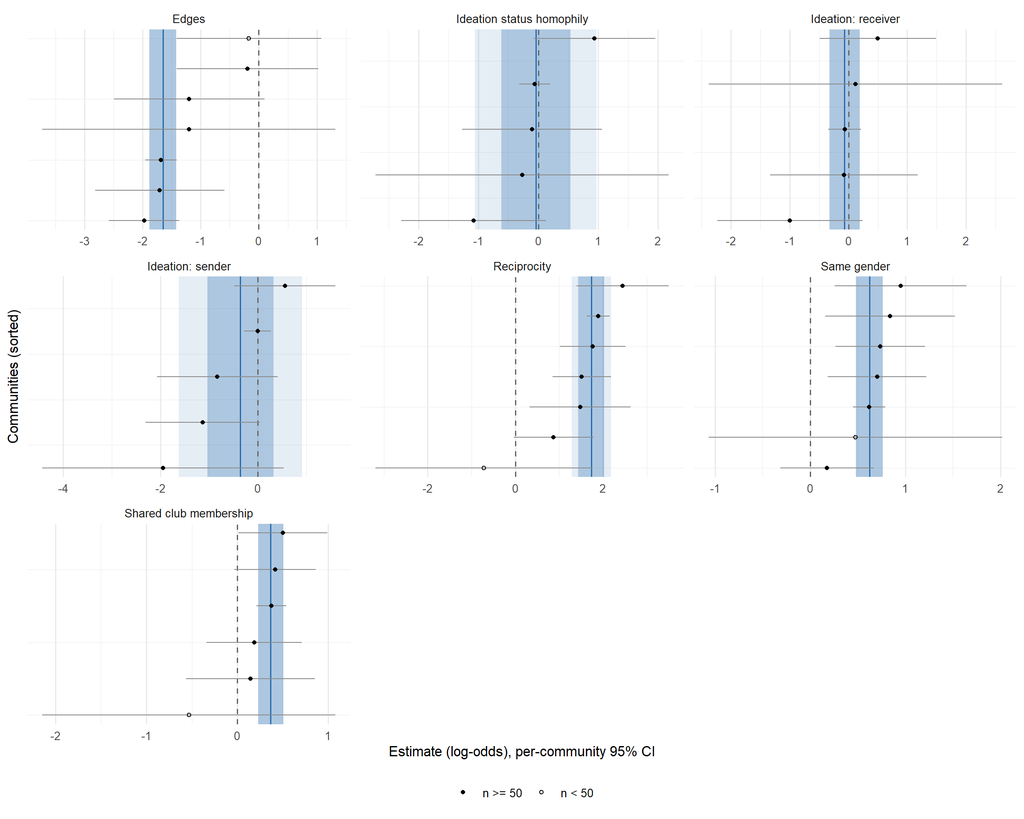

| Term | k | Coverage | I² (%) | Q p | T² p | LOO shift (SE) | Most influential | Small-comm. shift | Attrition shift | SE>5 shift | Size p | Integrated z | AIC FE / RE | Verdict |
| --- | --- | --- | --- | --- | --- | --- | --- | --- | --- | --- | --- | --- | --- | --- |
| Shared club membership | 5 | 31% | 0 | 0.88 | 4e-05 | 0.29 | 458 | 0.09 | — | — | 0.798 | — | -3 / -1 | poor |
| Edges | 6 | 38% | 0 | 0.2 | 9.7e-41 | 2.50 | 475 | 2.86 | — | — | 0.994 | — | 12 / 14 | poor |
| Reciprocity | 6 | 38% | 20 | 0.23 | 4.3e-56 | 0.96 | 458 | 0.43 | — | — | 0.653 | — | 8 / 10 | poor |
| Ideation: receiver | 5 | 31% | 0 | 0.48 | 0.59 | 0.32 | 428 | — | — | — | 0.913 | — | 8 / 10 | poor |
| Same gender | 6 | 38% | 0 | 0.45 | 3.6e-15 | 0.56 | 405 | 0.02 | — | — | 0.857 | — | 0 / 2 | poor |
| Ideation status homophily | 5 | 31% | 44 | 0.17 | 0.25 | 0.52 | 428 | — | — | — | 0.907 | — | 11 / 13 | poor |
| Ideation: sender | 5 | 31% | 56 | 0.079 | 0.12 | 0.96 | 428 | — | — | — | 0.431 | — | 13 / 15 | poor |

**Communities not pooled (8)**

| Community | Nodes | Status | Reason | Method |
| --- | --- | --- | --- | --- |
| 401 | 45 | too few events | formed = 40, dissolved = 8 (minimum 10) |  |
| 402 | 61 | degenerate |  | Stochastic-Approximation |
| 403 | 123 | degenerate |  | Stochastic-Approximation |
| 404 | 99 | degenerate |  | Stochastic-Approximation |
| 406 | 83 | degenerate |  | Stochastic-Approximation |
| 436 | 53 | degenerate |  | Stochastic-Approximation |
| 463 | 43 | degenerate |  | Stochastic-Approximation |
| 477 | 1721 | degenerate |  | Stochastic-Approximation |

#### m7 step 3 — dissolution

Each point is one community’s estimate with its 95% CI (open circles: small communities, n < 50). The blue line is the pooled estimate; the dark band its 95% CI and the light band the 95% prediction interval.

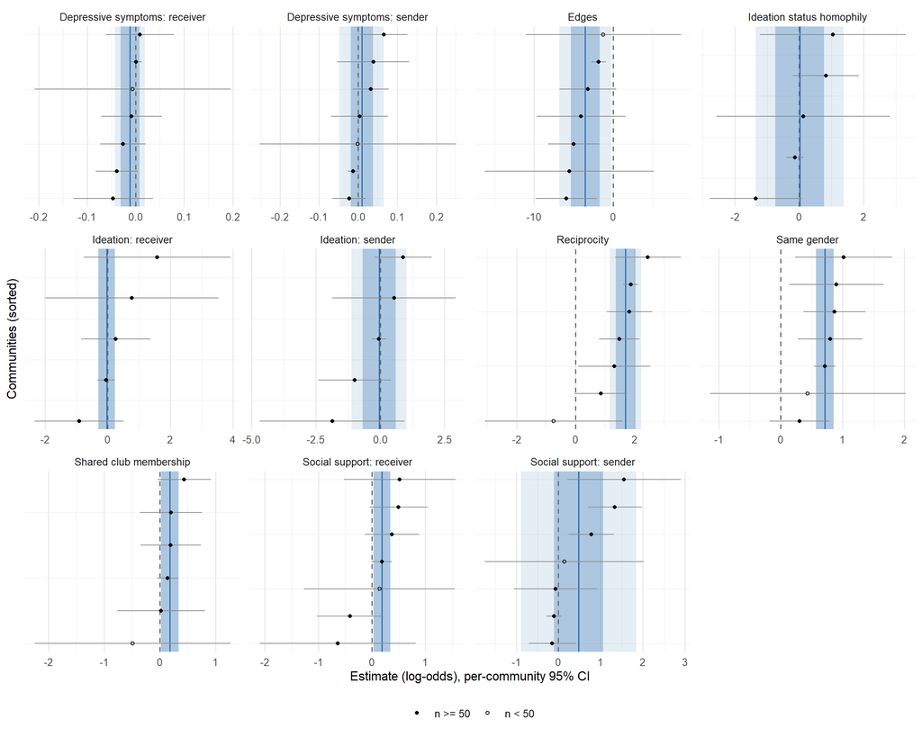

| Term | k | Coverage | I² (%) | Q p | T² p | LOO shift (SE) | Most influential | Small-comm. shift | Attrition shift | SE>5 shift | Size p | Integrated z | AIC FE / RE | Verdict |
| --- | --- | --- | --- | --- | --- | --- | --- | --- | --- | --- | --- | --- | --- | --- |
| Shared club membership | 5 | 31% | 0 | 0.84 | 0.28 | 1.00 | 458 | 0.07 | — | — | 0.623 | — | -2 / 0 | poor |
| Edges | 6 | 38% | 42 | 0.16 | 6.9e-07 | 1.19 | 458 | 0.11 | — | 0.05 | 0.013 | — | 29 / 29 | poor |
| Reciprocity | 6 | 38% | 27 | 0.19 | 2.6e-56 | 0.84 | 458 | 0.49 | — | — | 0.664 | — | 9 / 11 | poor |
| Depressive symptoms: receiver | 6 | 38% | 25 | 0.4 | 0.45 | 1.36 | 458 | 0.02 | — | — | 0.081 | — | -27 / -25 | poor |
| Ideation: receiver | 5 | 31% | 0 | 0.42 | 0.56 | 1.24 | 458 | — | — | — | 0.594 | — | 10 / 12 | poor |
| Social support: receiver | 6 | 38% | 0 | 0.23 | 0.056 | 0.67 | 428 | 0.01 | — | — | 0.942 | — | 6 / 8 | poor |
| Same gender | 6 | 38% | 0 | 0.55 | 1.2e-18 | 0.55 | 405 | 0.03 | — | — | 0.955 | — | 0 / 2 | poor |
| Ideation status homophily | 5 | 31% | 51 | 0.13 | 0.18 | 0.60 | 428 | — | — | — | 0.650 | — | 13 / 15 | poor |
| Depressive symptoms: sender | 6 | 38% | 57 | 0.055 | 0.061 | 0.92 | 408 | 0.02 | — | — | 0.438 | — | -21 / -20 | poor |
| Ideation: sender | 5 | 31% | 35 | 0.17 | 0.26 | 0.62 | 408 | — | — | — | 0.865 | — | 13 / 15 | poor |
| Social support: sender | 6 | 38% | 84 | 1.1e-05 | 2e-05 | 0.73 | 408 | 0.09 | — | — | 0.437 | — | 30 / 16 | poor |

**Communities not pooled (8)**

| Community | Nodes | Status | Reason | Method |
| --- | --- | --- | --- | --- |
| 401 | 45 | too few events | formed = 40, dissolved = 8 (minimum 10) |  |
| 402 | 61 | degenerate |  | Stochastic-Approximation |
| 403 | 123 | degenerate |  | Stochastic-Approximation |
| 404 | 99 | degenerate |  | Stochastic-Approximation |
| 407 | 161 | degenerate |  | Stochastic-Approximation |
| 436 | 53 | degenerate |  | Stochastic-Approximation |
| 463 | 43 | degenerate |  | Stochastic-Approximation |
| 477 | 1721 | degenerate |  | Stochastic-Approximation |

#### m7 step 3 — dissolution

Each point is one community’s estimate with its 95% CI (open circles: small communities, n < 50). The blue line is the pooled estimate; the dark band its 95% CI and the light band the 95% prediction interval.

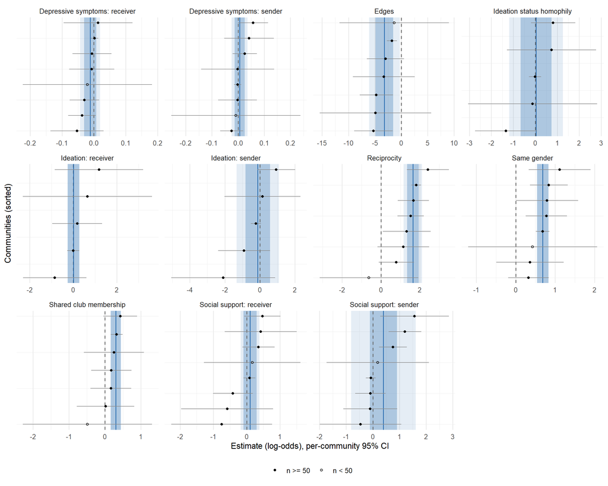

| Term | k | Coverage | I² (%) | Q p | T² p | LOO shift (SE) | Most influential | Small-comm. shift | Attrition shift | SE>5 shift | Size p | Integrated z | AIC FE / RE | Verdict |
| --- | --- | --- | --- | --- | --- | --- | --- | --- | --- | --- | --- | --- | --- | --- |
| Shared club membership | 6 | 38% | 0 | 0.94 | 0.0038 | 0.80 | 458 | 0.07 | — | — | 0.517 | — | -2 / 0 | poor |
| Edges | 6 | 38% | 37 | 0.26 | 5.3e-06 | 1.25 | 458 | 0.08 | — | 0.04 | 0.027 | — | 27 / 28 | poor |
| Reciprocity | 7 | 44% | 20 | 0.27 | 2.2e-54 | 0.99 | 458 | 0.37 | — | — | 0.374 | — | 10 / 12 | poor |
| Depressive symptoms: receiver | 7 | 44% | 23 | 0.45 | 0.52 | 1.39 | 458 | 0.01 | — | — | 0.056 | — | -30 / -28 | poor |
| Ideation: receiver | 5 | 31% | 0 | 0.58 | 0.72 | 0.42 | 458 | — | — | — | 0.734 | — | 9 / 11 | poor |
| Social support: receiver | 7 | 44% | 12 | 0.22 | 0.2 | 0.65 | 428 | 0.03 | — | — | 0.860 | — | 8 / 10 | poor |
| Same gender | 7 | 44% | 0 | 0.65 | 4.1e-17 | 0.41 | 405 | 0.03 | — | — | 0.997 | — | 1 / 3 | poor |
| Ideation status homophily | 5 | 31% | 46 | 0.17 | 0.27 | 0.62 | 408 | — | — | — | 0.804 | — | 13 / 15 | poor |
| Depressive symptoms: sender | 7 | 44% | 21 | 0.34 | 0.44 | 0.86 | 458 | 0.03 | — | — | 0.691 | — | -28 / -26 | poor |
| Ideation: sender | 5 | 31% | 42 | 0.14 | 0.12 | 0.41 | 428 | — | — | — | 0.951 | — | 13 / 15 | poor |
| Social support: sender | 7 | 44% | 79 | 8.5e-05 | 0.0001 | 0.68 | 408 | 0.05 | — | — | 0.577 | — | 28 / 18 | poor |

**Communities not pooled (7)**

| Community | Nodes | Status | Reason | Method |
| --- | --- | --- | --- | --- |
| 401 | 45 | too few events | formed = 40, dissolved = 8 (minimum 10) |  |
| 403 | 123 | degenerate |  | Stochastic-Approximation |
| 404 | 99 | degenerate |  | Stochastic-Approximation |
| 407 | 161 | degenerate |  | Stochastic-Approximation |
| 436 | 53 | degenerate |  | Stochastic-Approximation |
| 463 | 43 | degenerate |  | Stochastic-Approximation |
| 477 | 1721 | degenerate |  | Stochastic-Approximation |

## Fit & Convergence

Fit status by model and sub-model (communities)

| Model | Part | degenerate | fit | too few events |
| --- | --- | --- | --- | --- |
| m7f1d1 | dissolution | 4 | 11 | 1 |
| m7f1d1 | formation | 1 | 14 | 1 |
| m7f2d2 | dissolution | 7 | 8 | 1 |
| m7f2d2 | formation | 1 | 14 | 1 |
| m7f3d3 | dissolution | 7 | 8 | 1 |
| m7f3d3 | formation | 5 | 10 | 1 |
| m7f4d3 | dissolution | 6 | 9 | 1 |
| m7f4d3 | formation | 3 | 12 | 1 |

Formation and dissolution events per community (shared nodes, wave 1 -> wave 2)

| Model | Median arcs formed | Median arcs dissolved | Fewest formed | Fewest dissolved |
| --- | --- | --- | --- | --- |
| m7f1d1 | 121.5 | 105 | 32 | 8 |
| m7f2d2 | 121.5 | 105 | 32 | 8 |
| m7f3d3 | 121.5 | 105 | 32 | 8 |
| m7f4d3 | 121.5 | 105 | 32 | 8 |

## Goodness of Fit

Share of communities with poor fit, by GOF statistic

| Model | dist | espart | ideg | model | odeg |
| --- | --- | --- | --- | --- | --- |
| m7f1d1 | 85% of 13 | 100% of 13 | 85% of 13 | 8% of 13 | 100% of 13 |
| m7f2d2 | 93% of 15 | 100% of 15 | 93% of 15 | 40% of 15 | 100% of 15 |
| m7f3d3 | 93% of 15 | 100% of 15 | 93% of 15 | 40% of 15 | 93% of 15 |
| m7f4d3 | 93% of 15 | 100% of 15 | 93% of 15 | 33% of 15 | 93% of 15 |

Each community’s GOF plots are in **By Community**.

## Collinearity Flags

Flagged pairs (number of communities)

| Model | Term 1 | Term 2 | Communities |
| --- | --- | --- | --- |
| m7f1d1 | Edges | Ideation status homophily | 20 |
| m7f1d1 | Edges | Ideation: sender | 17 |
| m7f1d1 | Edges | Ideation: receiver | 14 |
| m7f1d1 | Ideation status homophily | Ideation: receiver | 13 |
| m7f1d1 | Ideation status homophily | Ideation: sender | 12 |
| m7f2d2 | Edges | Ideation status homophily | 12 |
| m7f4d3 | Depressive symptoms: receiver | Depressive symptoms squared: receiver | 8 |
| m7f4d3 | Depressive symptoms: sender | Depressive symptoms squared: sender | 8 |
| m7f3d3 | Ideation status homophily | Ideation: receiver | 7 |
| m7f4d3 | Ideation status homophily | Ideation: receiver | 7 |
| m7f2d2 | Edges | Ideation: sender | 6 |
| m7f2d2 | Ideation status homophily | Ideation: receiver | 6 |
| m7f3d3 | Ideation status homophily | Ideation: sender | 6 |
| m7f1d1 | Ideation: receiver | Ideation: sender | 5 |
| m7f2d2 | Ideation status homophily | Ideation: sender | 5 |
| m7f4d3 | Ideation status homophily | Ideation: sender | 5 |
| m7f2d2 | Edges | Ideation: receiver | 4 |
| m7f3d3 | Edges | Social support: receiver | 3 |
| m7f3d3 | Ideation: receiver | Ideation: sender | 2 |
| m7f4d3 | Edges | Social support: receiver | 2 |
| m7f4d3 | Edges | Social support: sender | 2 |
| m7f4d3 | Ideation: receiver | Ideation: sender | 2 |
| m7f2d2 | Ideation: receiver | Ideation: sender | 1 |
| m7f3d3 | Edges | Ideation status homophily | 1 |
| m7f3d3 | Edges | Ideation: receiver | 1 |
| m7f3d3 | Edges | Ideation: sender | 1 |
| m7f3d3 | Edges | Social support: sender | 1 |
| m7f4d3 | Edges | Ideation status homophily | 1 |
| m7f4d3 | Edges | Ideation: receiver | 1 |
| m7f4d3 | Edges | Ideation: sender | 1 |

# References

- An, W. (2015). Multilevel meta network analysis with application to studying network dynamics of network interventions. *Social Networks*, 43, 48–56.
- Krivitsky, P. N., Coletti, P., & Hens, N. (2023). A tale of two datasets: Representativeness and generalisability of inference for samples of networks. *Journal of the American Statistical Association*.
- Snijders, T. A. B. (2002). Markov chain Monte Carlo estimation of exponential random graph models. *Journal of Social Structure*, 3(2).
- Snijders, T. A. B., & Baerveldt, C. (2003). A multilevel network study of the effects of delinquent behavior on friendship evolution. *Journal of Mathematical Sociology*, 27, 123–151.
- Tolochko, P., & Boomgaarden, H. G. (2024). Same but different: A comparison of estimation approaches for exponential random graph models for multiple networks. *Social Networks*, 76, 1–11.